# Correlation Analyses

Joey Hulbert

2/6/2022

### Purpose

The purpose of this analysis document is to ensure the reproducability of the results by guiding the reader through the random forest analysis of the factors associated with the health of western redcedar.

In this document, we explore the correlation between explanitory variables.

### Approach

Root data were shared by citizen scientists in the [Wester Redcedar Dieback Map](https://www.inaturalist.org/projects/western-redcedar-dieback-map) project on iNaturalist.

- These data were then combined with
- Climate data derived using the ClimateNA tool. Instructions for how this tool was used are included in the climate subfolder.
- Topographic data extraced from DEM rasters. Preliminary methods for extracting topo data from GPS points are available in the topo subfolder.
- Soils data downloaded from gSSURRGO databases for Washington and Oregon. Instructions for extracting the soils data using Arc GIS Pro are included in the soils subfolder.

All of the data used in the below analyses are described in the Data Wrangle folder.

### Data

The data used in the below visualizations are described in the Data Wrangle folder.

### Climate variables averaged over last decade ‘2011 to 2020’

Subset lastdecade data to only numeric variables without zero variance (remove columns that only have one value for every ob)

[figure not shown]

[output not shown]

[output cut: 21342 more lines]

[output not shown]

### Soils data

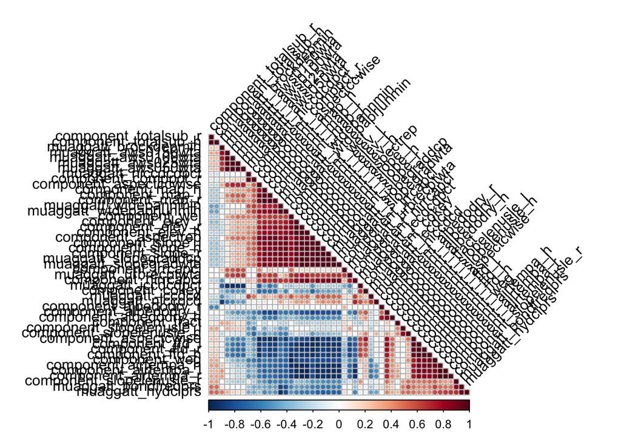

[output not shown]

[output cut: 3252 more lines]

[output not shown]

```
## $r
##                           row                   column      cor       p
## 1        component_totalsub_r     component_totalsub_h  1.00000 0.0e+00
## 2        component_totalsub_r     muaggatt_brockdepmin  0.22000 4.2e-01
## 3        component_totalsub_h     muaggatt_brockdepmin  0.22000 4.2e-01
## 4        component_totalsub_r      muaggatt_aws0150wta  0.34000 6.0e-02
## 5        component_totalsub_h      muaggatt_aws0150wta  0.34000 6.0e-02
## 6        muaggatt_brockdepmin      muaggatt_aws0150wta  0.79000 9.9e-03
## 7        component_totalsub_r      muaggatt_aws0100wta  0.28000 9.6e-02
## 8        component_totalsub_h      muaggatt_aws0100wta  0.28000 9.6e-02
## 9        muaggatt_brockdepmin      muaggatt_aws0100wta  0.74000 2.9e-02
## 10        muaggatt_aws0150wta      muaggatt_aws0100wta  0.99000 4.8e-37
## 11       component_totalsub_r       muaggatt_aws025wta  0.28000 2.9e-01
## 12       component_totalsub_h       muaggatt_aws025wta  0.28000 2.9e-01
## 13       muaggatt_brockdepmin       muaggatt_aws025wta  0.66000 1.3e-01
```

[output cut: 1169 more lines]

Evaluating pnwsoils.corr.values.low.corr shows some factors that need to be removed (e.g. OID_ field_1 lat long id cokey mukey )

## All data combined

Filter trees to only those with soils data (Oregon and Washington)

All tree health categories

```
## # A tibble: 11 × 2
## # Groups:   field.tree.canopy.symptoms [11]
##    field.tree.canopy.symptoms                             n
##    <fct>                                              <int>
##  1 Branch Dieback or 'Flagging'                          19
##  2 Browning Canopy                                       19
##  3 Extra Cone Crop                                        2
##  4 Healthy                                              403
##  5 Multiple Symptoms (please list in Notes)              17
##  6 New Dead Top (red or brown needles still attached)    33
##  7 Old Dead Top (needles already gone)                   83
##  8 Other (please describe in Notes)                       8
##  9 Thinning Canopy                                      118
## 10 Tree is dead                                          37
## 11 Yellowing Canopy                                      10
```

#### Filter Data

We need to filter the data to only include response and explanatory variables we’re interested in. For example, whether a sound clip was included in the iNat data is not important.

We also need to remove other response variables like “field.percent.canopy.affected….” so it is not used as a predictor for tree health.

> Note it might be interesting to know if the user was an important factor in predicting if the tree is healthy/unhealthy.

There are also a number of factors that should probably be removed because they may be biasing the data. For example, only trees with the ‘other factor’ question may only be answered for unhealthy trees. We need to think about this a bit more.

Remove variables with variables that have near zero standard deviations (entire column is same value)